# RePsychLing Kliegl et al. (2011)

Author

Reinhold Kliegl

Published

2026-03-31

# 1 Background

We take the `kwdyz11` dataset (Kliegl et al., 2011) from an experiment looking at three effects of visual cueing under four different cue-target relations (CTRs). Two horizontal rectangles are displayed above and below a central fixation point or they displayed in vertical orientation to the left and right of the fixation point. Subjects react to the onset of a small visual target occurring at one of the four ends of the two rectangles. The target is cued validly on 70% of trials by a brief flash of the corner of the rectangle at which it appears; it is cued invalidly at the three other locations 10% of the trials each.

We specify three contrasts for the four-level factor CTR that are derived from spatial, object-based, and attractor-like features of attention. They map onto sequential differences between appropriately ordered factor levels. At the level of fixed effects, there is the noteworthy result, that the attraction effect was estimated at 2 ms, that is clearly not significant. Nevertheless, there was a highly reliable variance component (VC) estimated for this effect. Moreover, the reliable individual differences in the attraction effect were negatively correlated with those in the spatial effect.

Unfortunately, a few years after the publication, we determined that the reported LMM is actually singular and that the singularity is linked to a theoretically critical correlation parameter (CP) between the spatial effect and the attraction effect. Fortunately, there is also a larger dataset `kkl15` from a replication and extension of this study (Kliegl et al., 2015), analyzed with `kkl15.jl` notebook. The critical CP (along with other fixed effects and CPs) was replicated in this study.

A more comprehensive analysis was reported in the parsimonious mixed-model paper (Bates et al., 2015). Data and R scripts are also available in [R-package RePsychLing](https://github.com/dmbates/RePsychLing/tree/master/data/). In this and the complementary `kkl15.jl` scripts, we provide some corresponding analyses with *MixedModels.jl*.

# 2 Packages

```julia
using AlgebraOfGraphics
using AlgebraOfGraphics: density
using CairoMakie
using CategoricalArrays
using Chain
using DataFrames
using DataFrameMacros
using Distributions
using MixedModels
using MixedModelsMakie
using Random
using SMLP2026: dataset, fit_or_restore
using StatsBase
```

# 3 Read data, compute and plot densities and means

```julia
dat = DataFrame(dataset(:kwdyz11))
describe(dat)
```

5×7 DataFrame

| Row | variable Symbol | mean Union… | min Any | median Union… | max Any | nmissing Int64 | eltype DataType |
| --- | --- | --- | --- | --- | --- | --- | --- |
| 1 | Item |  | I002 |  | I603 | 0 | String |
| 2 | Subj |  | S01 |  | S61 | 0 | String |
| 3 | CTR |  | dod |  | val | 0 | String |
| 4 | dir |  | hor |  | ver | 0 | String |
| 5 | rt | 370.426 | 150.1 | 358.6 | 705.7 | 0 | Float32 |

We recommend to code the levels/units of random factor / grouping variable not as a number, but as a string starting with a letter and of the same length for all levels/units.

We also recommend to sort levels of factors into a meaningful order, that is overwrite the default alphabetic ordering. This is also a good place to choose alternative names for variables in the context of the present analysis.

The LMM analysis is based on log-transformed reaction times `lrt`, indicated by a *boxcox()* check of model residuals. With the exception of diagnostic plots of model residuals, the analysis of untransformed reaction times did not lead to different results and exhibited the same problems of model identification (see Kliegl et al., 2011).

Comparative density plots of all response times by cue-target relation, Figure 1, show the times for valid cues to be faster than for the other conditions.

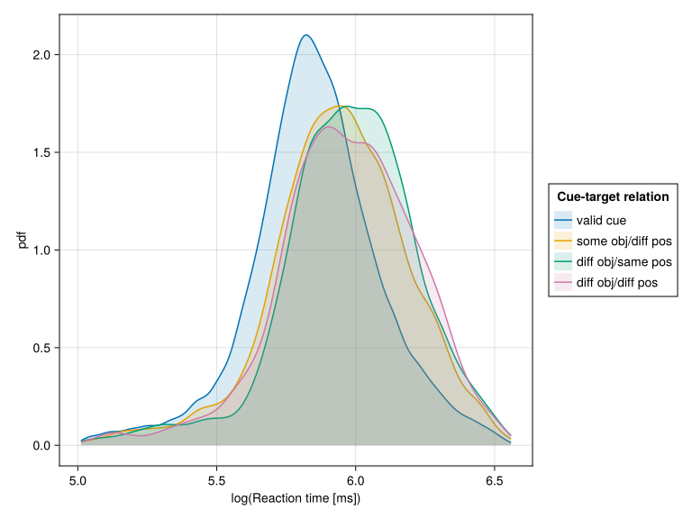

Figure 1: Comparative density plots of log reaction time for different cue-target relations.

```julia
draw(
  data(dat) *
  mapping(
    :rt => log => "log(Reaction time [ms])";
    color=:CTR =>
      renamer("val" => "valid cue", "sod" => "some obj/diff pos", "dos" => "diff obj/same pos", "dod" => "diff obj/diff pos") => "Cue-target relation",
  ) *
  density(),
)
```

An alternative visualization without overlap of the conditions can be accomplished with ridge plots.

**To be done**

For the next set of plots we average subjects’ data within the four experimental conditions. This table could be used as input for a repeated-measures ANOVA.

```julia
dat_subj = combine(
  groupby(dat, [:Subj, :CTR]),
  :rt => length => :n,
  :rt => mean => :rt_m,
  :rt => (r -> mean(log, r)) => :lrt_m,
)
dat_subj.CTR = categorical(dat_subj.CTR, levels=levels(dat.CTR))
dat_subj
```

244×5 DataFrame

219 rows omitted

| Row | Subj String | CTR Cat… | n Int64 | rt_m Float32 | lrt_m Float32 |
| --- | --- | --- | --- | --- | --- |
| 1 | S01 | val | 330 | 413.332 | 6.01272 |
| 2 | S01 | sod | 48 | 437.721 | 6.0682 |
| 3 | S01 | dos | 47 | 443.366 | 6.08269 |
| 4 | S01 | dod | 45 | 434.316 | 6.06079 |
| 5 | S02 | val | 333 | 365.899 | 5.87511 |
| 6 | S02 | sod | 47 | 396.149 | 5.95916 |
| 7 | S02 | dos | 46 | 439.487 | 6.06949 |
| 8 | S02 | dod | 48 | 441.042 | 6.06883 |
| 9 | S03 | val | 336 | 371.446 | 5.90489 |
| 10 | S03 | sod | 46 | 446.854 | 6.09464 |
| 11 | S03 | dos | 48 | 471.302 | 6.14287 |
| 12 | S03 | dod | 47 | 476.532 | 6.15706 |
| 13 | S04 | val | 336 | 403.181 | 5.99124 |
| ⋮ | ⋮ | ⋮ | ⋮ | ⋮ | ⋮ |
| 233 | S59 | val | 330 | 313.032 | 5.72433 |
| 234 | S59 | sod | 46 | 304.852 | 5.70367 |
| 235 | S59 | dos | 48 | 342.612 | 5.80927 |
| 236 | S59 | dod | 47 | 308.191 | 5.71206 |
| 237 | S60 | val | 330 | 372.835 | 5.90832 |
| 238 | S60 | sod | 48 | 382.087 | 5.93183 |
| 239 | S60 | dos | 44 | 395.109 | 5.96918 |
| 240 | S60 | dod | 47 | 387.689 | 5.95208 |
| 241 | S61 | val | 320 | 312.374 | 5.72542 |
| 242 | S61 | sod | 45 | 383.002 | 5.92798 |
| 243 | S61 | dos | 45 | 357.998 | 5.85563 |
| 244 | S61 | dod | 46 | 391.087 | 5.95344 |

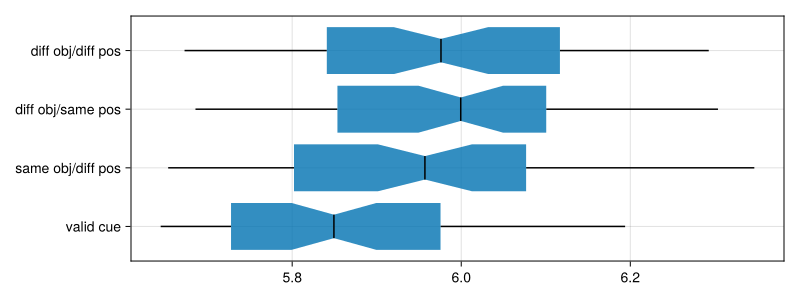

Figure 2: Comparative boxplots of log response time by cue-target relation.

```julia
boxplot(
  dat_subj.CTR.refs,
  dat_subj.lrt_m;
  orientation=:horizontal,
  show_notch=true,
  axis=(;
    yticks=(
      1:4,
      [
        "valid cue",
        "same obj/diff pos",
        "diff obj/same pos",
        "diff obj/diff pos",
      ],
    ),
  ),
  figure=(; size=(800, 300)),
)
```

Mean of log reaction times for four cue-target relations. Targets appeared at (a) the cued position (valid) in a rectangle, (b) in the same rectangle cue, but at its other end, (c) on the second rectangle, but at a corresponding horizontal/vertical physical distance, or (d) at the other end of the second rectangle, that is $\sqrt{2}$ of horizontal/vertical distance diagonally across from the cue, that is also at larger physical distance compared to (c).

A better alternative to the boxplot is a dotplot. It also displays subjects’ condition means.

**To be done**

# 4 Linear mixed model

```julia
contrasts = Dict(
  :CTR => SeqDiffCoding(; levels=["val", "sod", "dos", "dod"]),
)
m1 = let
  form = @formula(log(rt) ~ 1 + CTR + (1 + CTR | Subj))
  fit(MixedModel, form, dat; contrasts)
end
```

```julia
VarCorr(m1)
```

|  | Column | Variance | Std.Dev | Corr. |  |  |
| --- | --- | --- | --- | --- | --- | --- |
| Subj | (Intercept) | 0.0207655 | 0.1441023 |  |  |  |
|  | CTR: sod | 0.0033847 | 0.0581783 | +0.48 |  |  |
|  | CTR: dos | 0.0007530 | 0.0274413 | -0.24 | -0.15 |  |
|  | CTR: dod | 0.0006220 | 0.0249409 | +0.30 | +0.93 | -0.43 |
| Residual |  | 0.0368543 | 0.1919748 |  |  |  |

```julia
issingular(m1)
```

```
true
```

LMM `m1` is not fully supported by the data; it is overparameterized. This is also visible in the PCA: only three, not four PCS are needed to account for all the variance and covariance in the random-effect structure. The problem is the +.93 CP for spatial `sod` and attraction `dod` effects.

```julia
first(MixedModels.PCA(m1))
```

```
Principal components based on correlation matrix
 (Intercept)   1.0     .      .      .
 CTR: sod      0.48   1.0     .      .
 CTR: dos     -0.24  -0.15   1.0     .
 CTR: dod      0.3    0.93  -0.43   1.0

Normalized cumulative variances:
[0.5886, 0.8095, 1.0, 1.0]

Component loadings
                PC1   PC2    PC3    PC4
 (Intercept)  -0.4   0.04   0.9    0.17
 CTR: sod     -0.6   0.4   -0.16  -0.68
 CTR: dos      0.33  0.91   0.06   0.23
 CTR: dod     -0.61  0.08  -0.41   0.68
```

# 5 Diagnostic plots of LMM residuals

Do model residuals meet LMM assumptions? Classic plots are

- Residual over fitted
- Quantiles of model residuals over theoretical quantiles of normal distribution

## 5.1 Residual-over-fitted plot

The slant in residuals show a lower and upper boundary of reaction times, that is we have have too few short and too few long residuals. Not ideal, but at least width of the residual band looks similar across the fitted values, that is there is no evidence for heteroskedasticity.

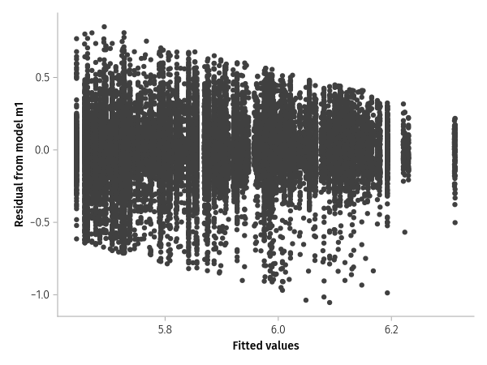

Figure 3: Residuals versus the fitted values for model m1 of the log response time.

```julia
set_aog_theme!()
draw(
  data((; f=fitted(m1), r=residuals(m1))) *
  mapping(:f => "Fitted values", :r => "Residual from model m1") *
  visual(Scatter);
)
```

With many observations the scatterplot is not that informative. Contour plots or heatmaps may be an alternative.

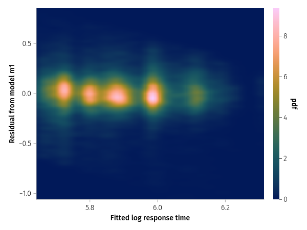

Figure 4: Heatmap of residuals versus fitted values for model m1

```julia
draw(
  data((; f=fitted(m1), r=residuals(m1))) *
  mapping(
    :f => "Fitted log response time", :r => "Residual from model m1"
  ) *
  density();
)
```

## 5.2 Q-Q plot

The plot of quantiles of model residuals over corresponding quantiles of the normal distribution should yield a straight line along the main diagonal.

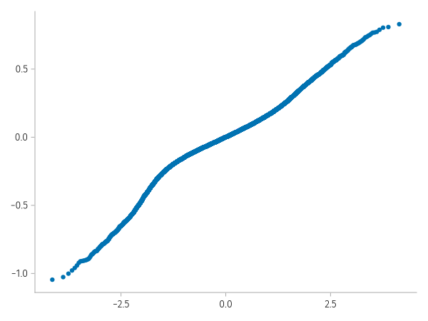

```julia
qqnorm(residuals(m1); qqline=:none)
```

## 5.3 Observed and theoretical normal distribution

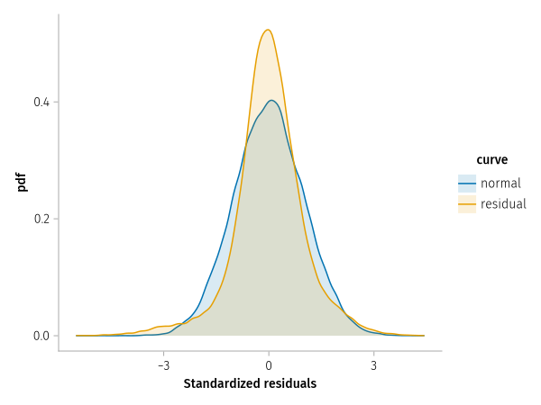

Figure 5: Kernel density plot of the standardized residuals from model m1 compared to a Gaussian

```julia
let
  n = nrow(dat)
  dat_rz = DataFrame(;
    value=vcat(residuals(m1) ./ std(residuals(m1)), randn(n)),
    curve=vcat(fill.("residual", n), fill.("normal", n)),
  )
  draw(
    data(dat_rz) *
    mapping(:value => "Standardized residuals"; color=:curve) *
    density(; bandwidth=0.1);
  )
end
```

# 6 Conditional modes

Now we move on to visualizations that are based on model parameters and subjects’ data, that is “predictions” of the LMM for subject’s GM and experimental effects. Three important plots are

- Overlay
- Caterpillar
- Shrinkage

## 6.1 Overlay

The first plot overlays shrinkage-corrected conditional modes of the random effects with within-subject-based and pooled GMs and experimental effects.

**To be done**

## 6.2 Caterpillar plot

The caterpillar plot, Figure 6, also reveals the high correlation between spatial `sod` and attraction `dod` effects.

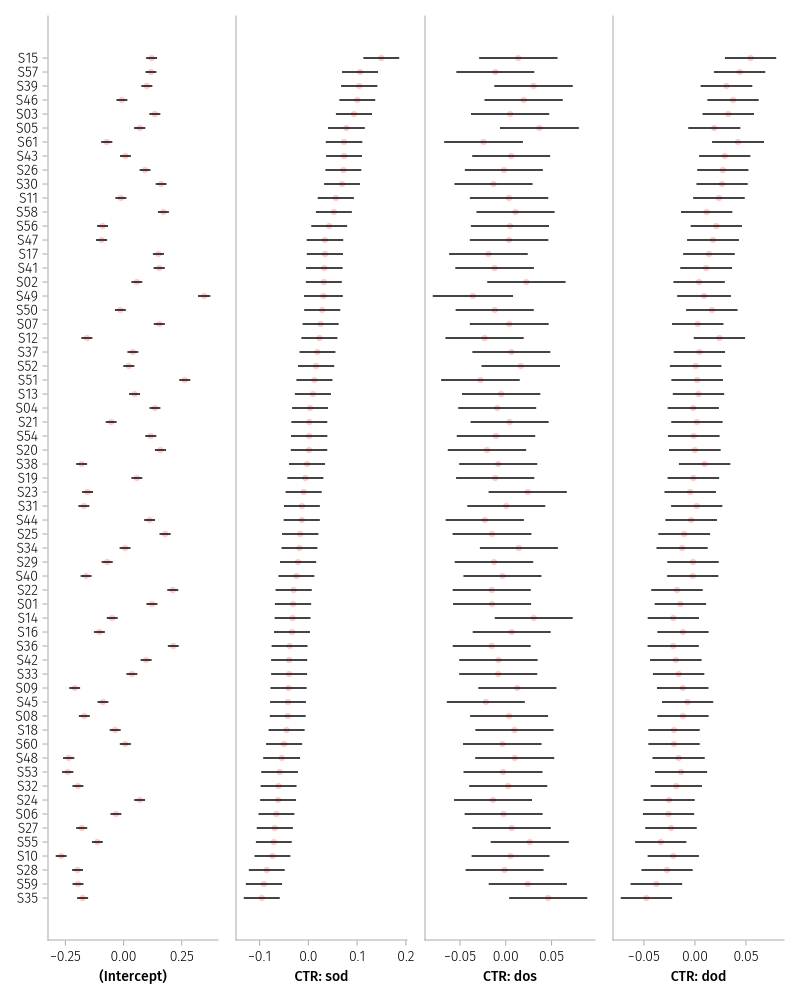

Figure 6: Prediction intervals on the random effects for Subj in model m1

```julia
caterpillar!(
  Figure(; size=(800, 1000)), ranefinfo(m1, :Subj); orderby=2
)
```

## 6.3 Shrinkage plot

Figure 7 provides more evidence for a problem with the visualization of the spatial `sod` and attraction `dod` CP. The corresponding panel illustrates an *implosion* of conditional modes.

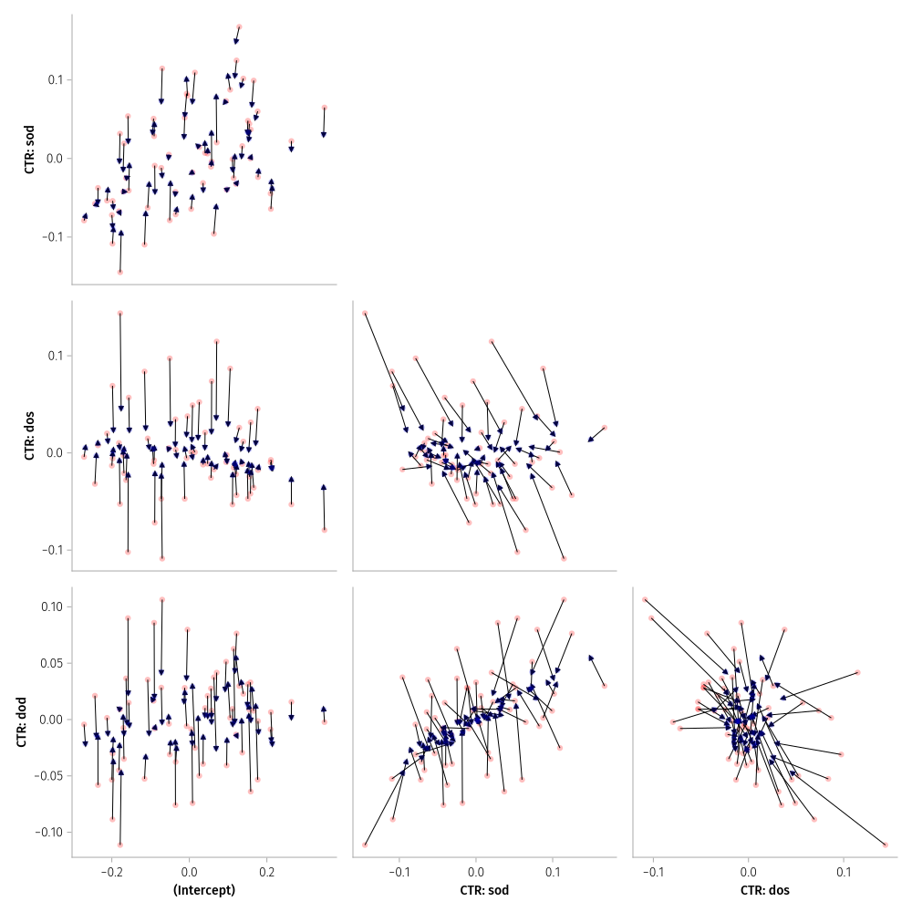

Figure 7: Shrinkage plot of the conditional means of the random effects for model m1

```julia
shrinkageplot!(Figure(; size=(1000, 1000)), m1)
```

# 7 Parametric bootstrap

Here we

- generate a bootstrap sample
- compute shortest covergage intervals for the LMM parameters
- plot densities of bootstrapped parameter estimates for residual, fixed effects, variance components, and correlation parameters

## 7.1 Generate a bootstrap sample

We generate 2500 samples for the 15 model parameters (4 fixed effect, 4 VCs, 6 CPs, and 1 residual).

```julia
Random.seed!(1234321)
samp = parametricbootstrap(2500, m1)
tbl = samp.tbl
```

```
Table with 26 columns and 2500 rows:
      obj       β1       β2         β3         β4           σ         ⋯
    ┌──────────────────────────────────────────────────────────────────
 1  │ -12780.3  5.92882  0.090329   0.0414833  -0.00664863  0.191959  ⋯
 2  │ -12744.1  5.94081  0.0983993  0.0320538  -0.00301866  0.192152  ⋯
 3  │ -13008.0  5.91439  0.0812454  0.0462893  -0.0131146   0.191086  ⋯
 4  │ -12877.3  5.94958  0.0986853  0.0354056  -0.0164526   0.19162   ⋯
 5  │ -12618.7  5.96242  0.0953757  0.0426122  -0.00245045  0.192605  ⋯
 6  │ -12930.3  5.95782  0.0880452  0.0286956  -0.0113569   0.191552  ⋯
 7  │ -12419.5  5.96508  0.0997065  0.0282138  -0.00930144  0.193267  ⋯
 8  │ -12448.6  5.91907  0.0972763  0.0413665  -0.00679077  0.193108  ⋯
 9  │ -12901.8  5.94039  0.0776491  0.0287677  -0.0197359   0.191522  ⋯
 10 │ -12902.2  5.92652  0.0720786  0.0389606  -0.00760412  0.191632  ⋯
 11 │ -12745.9  5.92423  0.0884694  0.0381242  -0.00675398  0.192067  ⋯
 12 │ -13014.2  5.93067  0.0938315  0.0332705  0.00494837   0.191092  ⋯
 13 │ -13249.4  5.88752  0.0882904  0.0390492  -0.00701679  0.190306  ⋯
 14 │ -12511.7  5.91759  0.070812   0.0457365  -0.014854    0.192887  ⋯
 15 │ -13041.7  5.9563   0.0953963  0.0357252  0.00111456   0.191246  ⋯
 16 │ -12322.5  5.9297   0.0857693  0.0348356  -0.0161299   0.193445  ⋯
 17 │ -13004.4  5.95912  0.094632   0.0371024  -0.0137208   0.191294  ⋯
 ⋮  │    ⋮         ⋮         ⋮          ⋮           ⋮          ⋮      ⋱
```

## 7.2 Shortest coverage interval

The upper limit of the interval for the critical CP `CTR: sod, CTR: dod` is hitting the upper wall of a perfect correlation. This is evidence of singularity. The other intervals do not exhibit such pathologies; they appear to be ok.

```julia
confint(samp)
```

```
DictTable with 2 columns and 15 rows:
 par   lower       upper
 ────┬──────────────────────
 β1  │ 5.89946     5.97084
 β2  │ 0.070812    0.102437
 β3  │ 0.0246617   0.0484437
 β4  │ -0.0205562  0.002207
 ρ1  │ 0.240074    0.684235
 ρ2  │ -0.754729   0.275429
 ρ3  │ -0.664696   0.456766
 ρ4  │ -0.196105   0.703365
 ρ5  │ 0.59055     0.999995
 ρ6  │ -0.892472   0.395342
 σ   │ 0.190506    0.193579
 σ1  │ 0.118879    0.169076
 σ2  │ 0.044985    0.0710407
 σ3  │ 0.00970091  0.0400901
 σ4  │ 0.0143777   0.038354
```

## 7.3 Comparative density plots of bootstrapped parameter estimates

## 7.4 Residual

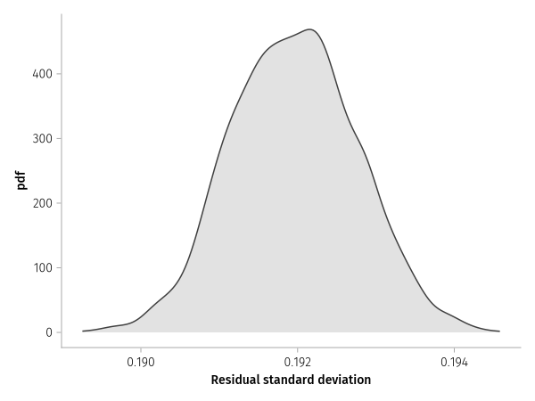

Figure 8

```julia
draw(
  data(tbl) *
  mapping(:σ => "Residual standard deviation") *
  density();
)
```

## 7.5 Fixed effects (w/o GM)

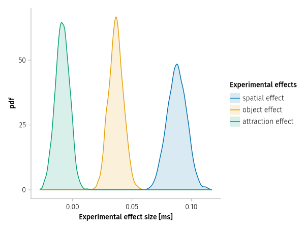

Figure 9: Comparative density plots of the fixed-effects parameters for model m1

```julia
labels = [
  "CTR: sod" => "spatial effect",
  "CTR: dos" => "object effect",
  "CTR: dod" => "attraction effect",
  "(Intercept)" => "grand mean",
]
draw(
  data(tbl) *
  mapping(
    [:β2, :β3, :β4] .=> "Experimental effect size [ms]";
    color=dims(1) => renamer(["spatial", "object", "attraction"] .* " effect") =>
    "Experimental effects",
  ) *
  density();
)
```

The densitiies correspond nicely with the shortest coverage intervals.

## 7.6 Variance components (VCs)

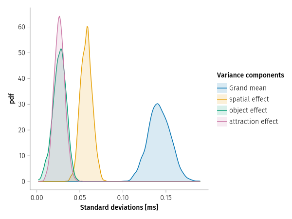

Figure 10: Comparative density plots of the variance components for model m1

```julia
draw(
  data(tbl) *
  mapping(
    [:σ1, :σ2, :σ3, :σ4] .=> "Standard deviations [ms]";
    color=dims(1) =>
    renamer(append!(["Grand mean"],["spatial", "object", "attraction"] .* " effect")) =>
    "Variance components",
  ) *
  density();
)
```

The VC are all very nicely defined.

## 7.7 Correlation parameters (CPs)

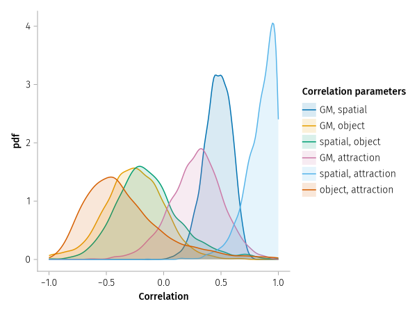

Figure 11: Comparative density plots of the correlation parameters for model m1

```julia
let
  labels = [
    "(Intercept), CTR: sod" => "GM, spatial",
    "(Intercept), CTR: dos" => "GM, object",
    "CTR: sod, CTR: dos" => "spatial, object",
    "(Intercept), CTR: dod" => "GM, attraction",
    "CTR: sod, CTR: dod" => "spatial, attraction",
    "CTR: dos, CTR: dod" => "object, attraction",
  ]
  draw(
    data(tbl) *
    mapping(
      [:ρ1, :ρ2, :ρ3, :ρ4, :ρ5, :ρ6] .=> "Correlation";
      color=dims(1) => renamer(last.(labels)) => "Correlation parameters",
    ) *
    density();
  )
end
```

Two of the CPs stand out positively. First, the correlation between GM and the spatial effect is well defined. Second, as discussed throughout this script, the CP between spatial and attraction effect is close to the 1.0 border and clearly not well defined. Therefore, this CP will be replicated with a larger sample in script `kkl15.jl` (Kliegl et al., 2015).

# 8 References

Bates, D., Kliegl, R., Vasishth, S., & Baayen, H. (2015). *Parsimonious mixed models*. arXiv. https://doi.org/10.48550/ARXIV.1506.04967

Kliegl, R., Kushela, J., & Laubrock, J. (2015). *Object orientation and target size modulate the speed of visual attention*. Department of Psychology, University of Potsdam.

Kliegl, R., Wei, P., Dambacher, M., Yan, M., & Zhou, X. (2011). Experimental effects and individual differences in linear mixed models: Estimating the relationship between spatial, object, and attraction effects in visual attention. *Frontiers in Psychology*. https://doi.org/10.3389/fpsyg.2010.00238

*This page was rendered from git revision [962c418](https://github.com/RePsychLing/SMLP2026/tree/962c418  
) using Quarto 1.9.36.*

Back to top